# Praca domowa 2

Wiktoria Postek

## Dane

Dane wykorzystane w Pracy domowej 2 dotyczą wyników egzaminów z 3 umiejętności: czytania, pisania i operacji matematycznych. Dodatkowo dostępne są podstawowe informacje o studentach i ich rodzicach. Opis wszystkich kolumn znajduje się również w pliku `README.md`.

| Zmienna | Opis |
| --- | --- |
| **gender** | płeć |
| **race.ethnicity** | pochodzenie etniczne |
| **parental.level.of.education** | wykształcenie rodziców |
| **lunch** | jaki obiad jedli uczniowie w dniu egzaminu |
| **test.preparation.course** | czy uczeń odbył kurs przygotowujący |
| **math.score** | wynik egzaminu z matematyki |
| **reading.score** | wynik egzaminu z czytania |
| **writing.score** | wynik egzaminu z pisania |

## Zadanie 1

Jak wyglądają rozkłady wyników uczniów z trzech przedmiotów (matematyka, czytanie, pisanie)?

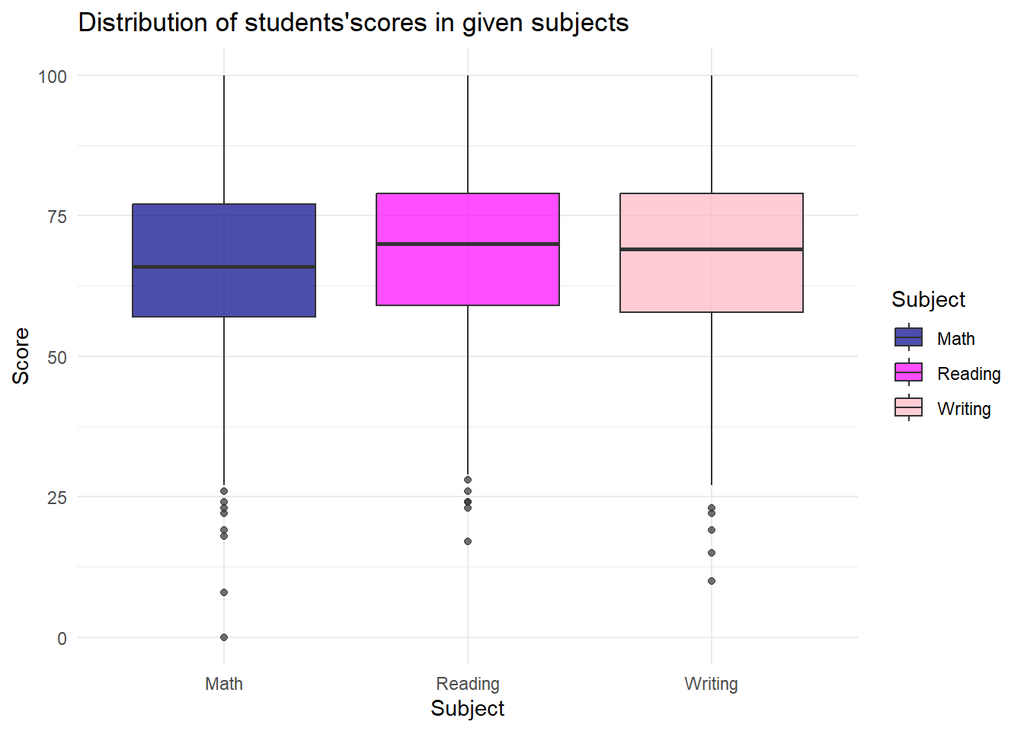

```r
df_long <- df %>%
  rename(Math = math.score,
         Reading = reading.score,
         Writing = writing.score) %>%
  pivot_longer(cols = c(Math, Writing, Reading),
               names_to = "subject",
               values_to = "score")

ggplot(df_long, aes(x = subject, y = score, fill = subject)) +
    geom_boxplot(alpha = 0.7) +
  theme_minimal() +
  labs(title = "Distribution of students'scores in given subjects",
              x = "Subject", y = "Score", fill = "Subject") +
  scale_fill_manual(values = c("darkblue", "magenta", "lightpink"))
```

**Komentarz:** Wykres pokazuje, że rozkłady wyników z wszystkich przedmiotów są do siebie zbliżone. Najniższą medianę uzyskano w przypadku matematyki, dla której pojawiło się też najwięcej niskich wartości odstających. Rozkłady wynikiów z czytania i pisania są bardzo podobne. Uczniowie uzyskali z tych przedmiotów trochę lepsze wyniki niż z egzaminu z matematyki.

## Zadanie 2

Czy istnieje zauważalna różnica w wynikach między uczniami i uczennicami?

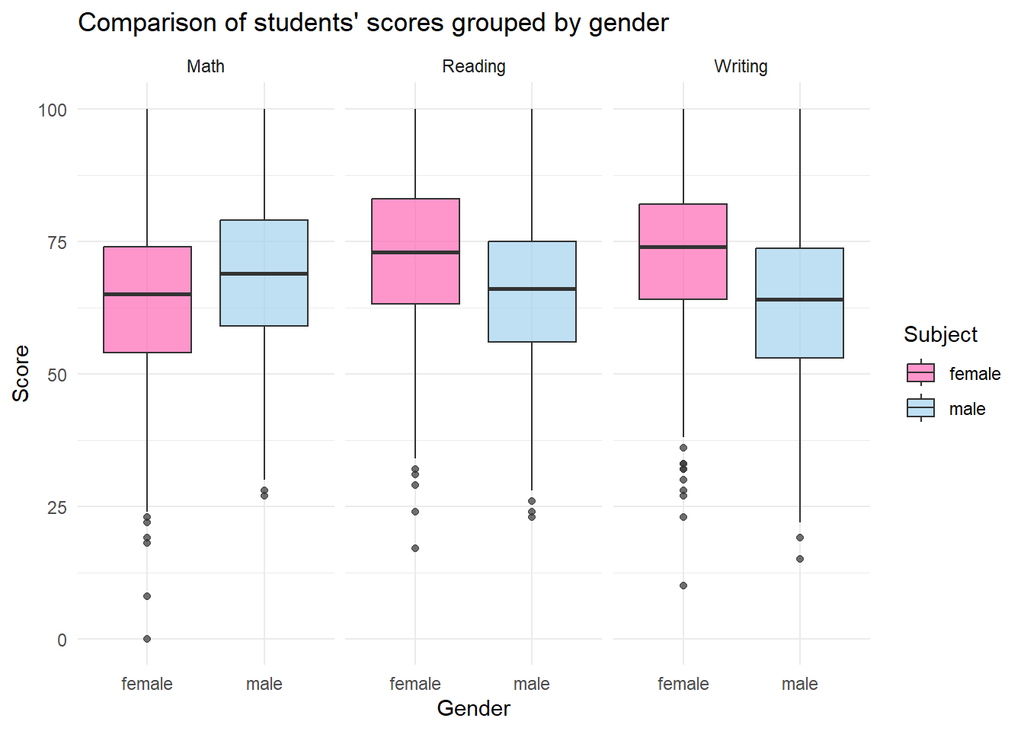

```r
ggplot(df_long, aes(x = gender, y = score, fill = gender)) +
    geom_boxplot(alpha = 0.7) +
  facet_wrap(~subject)+
  theme_minimal() +
  labs(title = "Comparison of students' scores grouped by gender",
       x = "Gender",
       y = "Score",
       fill = "Subject") +
  scale_fill_manual(values = c("hotpink", "lightskyblue2"))
```

**Komentarz:** Z powyższego wykresu można łatwo zauważyć, że uczennice osiągają średnio lepsze wyniki z egzaminu z czytania i pisania, natomiast uczniowie - z matematyki. Wśród uczennic jest również więcej wartości odstających.

## Zadanie 3

Czy uczniowie, którzy ukończyli kurs przygotowawczy, osiągają lepsze wyniki niż pozostali?

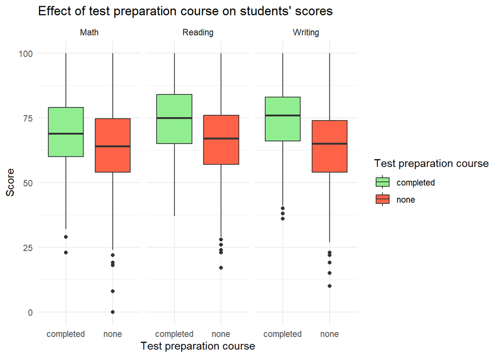

```r
df_long %>%
  ggplot(aes(x = test.preparation.course, y = score, fill = test.preparation.course))+
  geom_boxplot()+
  facet_wrap(~subject) +
  theme_minimal() +
  labs(title = "Effect of test preparation course on students' scores",
       x = "Test preparation course",
       y = "Score",
       fill = "Test preparation course")+
  scale_fill_manual(values = c("lightgreen", "tomato"))
```

**Komentarz:** Widać, że uczniowie, którzy ukończyli kurs przygotowawczy, uzyskali wyższe wyniki ze wszystkich przedmiotów, w porównaniu do osób, które nie ukończyły kursu. Największą różnicę widać w egzaminie z pisania, gdzie różnica mediany i zakresu pudełek jest najbardziej zauważalna.

## Zadanie 4

Jaki jest związek między poziomem wykształcenia rodziców a średnimi wynikami uczniów?

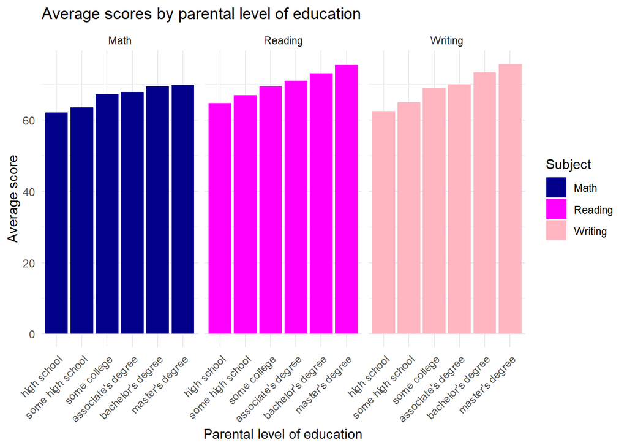

```r
df_4 <- df_long %>%
  group_by(parental.level.of.education, subject) %>%
  summarise(mean_score = mean(score))

ggplot(df_4, aes(x = reorder(parental.level.of.education, mean_score), y = mean_score, fill = subject))+
  facet_wrap(~subject)+
  geom_col()+
  theme_minimal() +
  labs(title = "Average scores by parental level of education",
       x = "Parental level of education",
       y = "Average score",
       fill = "Subject")+
  theme(axis.text.x = element_text(angle = 45, hjust = 1))+
  scale_fill_manual(values = c("darkblue", "magenta", "lightpink"))
```

## Zadanie 5

Czy płeć i wykształcenie rodzica wpływa na wynik z matematyki?

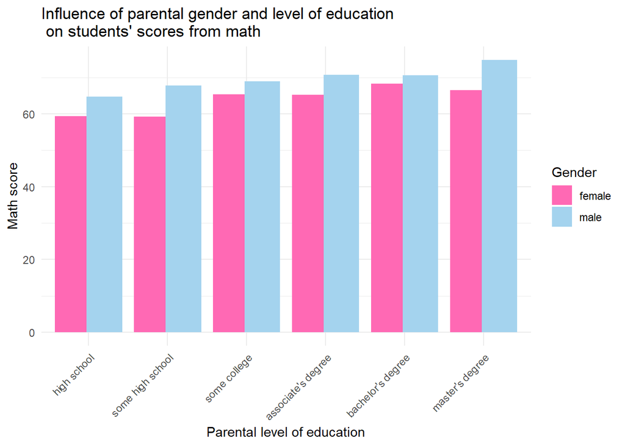

```r
df_5 <- df_long %>%
  filter(subject == "Math") %>%
  group_by(parental.level.of.education, gender) %>%
  summarise(mean_math = mean(score))

ggplot(df_5, aes(x = reorder(parental.level.of.education, mean_math), y = mean_math, fill = gender)) +
  geom_col(position = position_dodge(width = 0.8))+
  theme_minimal()+
  labs(title = "Influence of parental gender and level of education\n on students' scores from math",
       x = "Parental level of education",
       y = "Math score",
       fill = "Gender")+
  theme(axis.text.x = element_text(angle = 45, hjust = 1))+
   scale_fill_manual(values = c("hotpink", "lightskyblue2"))
```

## Zadanie 6

Czy istnieje zależność między wynikami z matematyki a wynikami z czytania lub pisania?

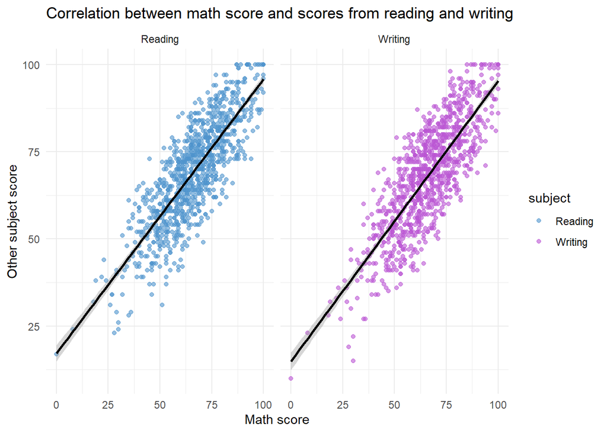

```r
df_long2 <- df %>%
  rename(Math = math.score,
         Reading = reading.score,
         Writing = writing.score) %>%
  pivot_longer(cols = c(Writing, Reading),
               names_to = "subject",
               values_to = "score")

ggplot(df_long2, aes(x = Math, y = score, color = subject))+
  geom_point(alpha = 0.6)+
  geom_smooth(method = "lm", color = "black")+
  facet_wrap(~subject) +
  theme_minimal()+
  scale_color_manual(values = c("steelblue3", "mediumorchid"))+
  labs(title = "Correlation between math score and scores from reading and writing",
       x = "Math score",
       y = "Other subject score",
       fill = "Subject")
```

**Komentarz:** Można zauważyć, że zarówno egzamin z czytania, jak i z pisania, jest silnie dodatnio skorelowany z egzaminem z matematyki. Uczniowie, którzy osiągają wysokie wyniki z matematyki, uzyskują też dobre rezultaty z egzaminów z czytania i pisania.